# Enrolment and Baseline

Exploratory summaries of enrolment and baseline data.

Author

James Totterdell

Published

July 26, 2023

# Enrolment

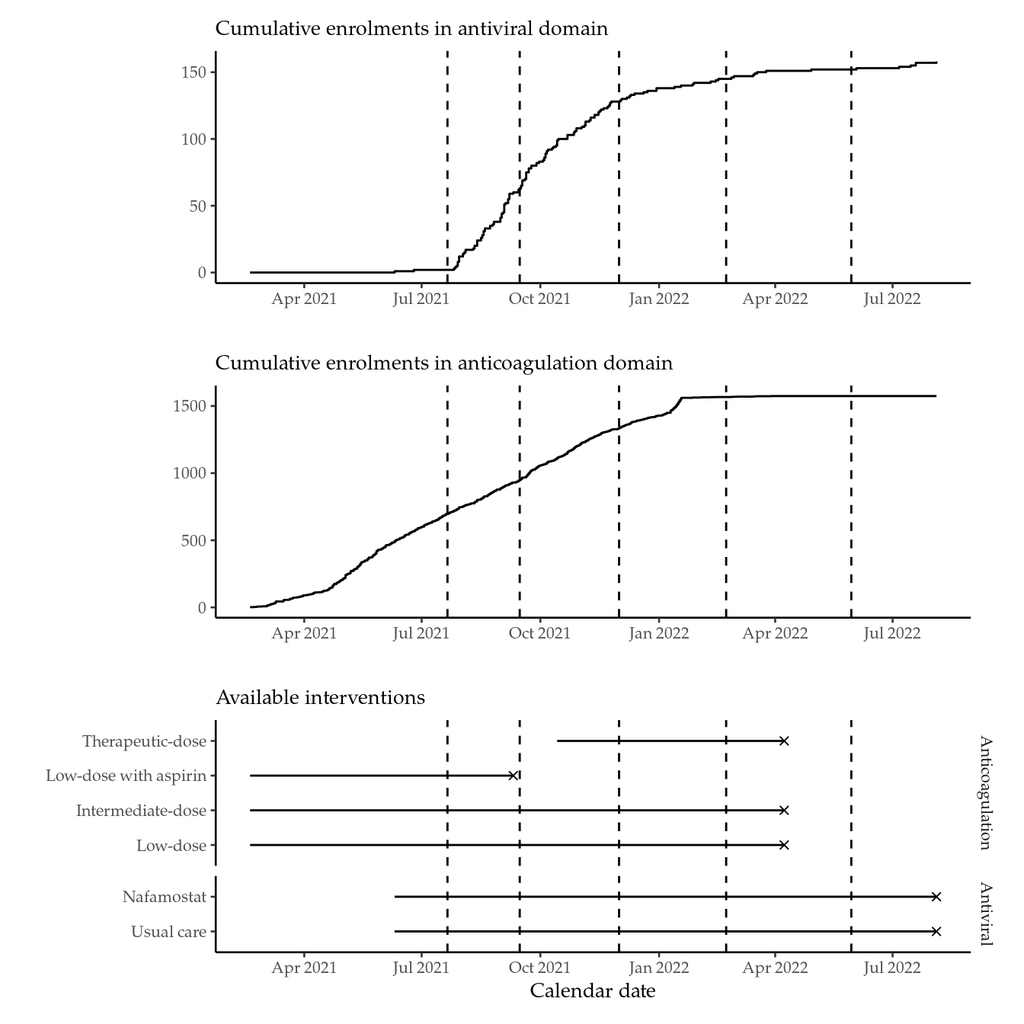

Figure 1: Cumulative enrolments to the platform, vertical lines indicate timing of interim analyses

# Intervention Assignments

| FAS_ITT | ACS_ITT | CAssignment | n |
| --- | --- | --- | --- |
| 1 | 0 | C0 | 32 |
| 1 | 1 | C1 | 610 |
| 1 | 1 | C2 | 613 |
| 1 | 1 | C3 | 283 |
| 1 | 1 | C4 | 50 |

Table 1: Counts of intervention assignments to anticoagulation domain.

| FAS_ITT | AVS_ITT | AAssignment | n |
| --- | --- | --- | --- |
| 1 | 0 | A0 | 1433 |
| 1 | 1 | A1 | 73 |
| 1 | 1 | A2 | 82 |

Table 2: Counts of intervention assignments to antiviral domain.

| Anticoagulation | Antiviral Not randomised A | Antiviral SoC | Antiviral Nafamostat | Total |
| --- | --- | --- | --- | --- |
| Not randomised C | 0 (0) | 18 (0) | 14 (0) | 32 (0) |
| Low | 569 (19) | 26 (0) | 24 (2) | 619 (21) |
| Intermediate | 566 (13) | 19 (0) | 35 (1) | 620 (14) |
| Low with aspirin | 278 (6) | 6 (0) | 1 (0) | 285 (6) |
| Therapeutic | 35 (0) | 4 (0) | 11 (0) | 50 (0) |
| Total | 1448 (38) | 73 (0) | 85 (3) | 1606 (41) |

Table 3: Distribution of interventions assigned to participants, FAS-ITT.

| Anticoagulation | Antiviral Not randomised A | Antiviral SoC | Antiviral Nafamostat | Total |
| --- | --- | --- | --- | --- |
| Low | 569 (19) | 26 (0) | 24 (2) | 619 (21) |
| Intermediate | 566 (13) | 19 (0) | 35 (1) | 620 (14) |
| Low with aspirin | 278 (6) | 6 (0) | 1 (0) | 285 (6) |
| Therapeutic | 35 (0) | 4 (0) | 11 (0) | 50 (0) |
| Total | 1448 (38) | 55 (0) | 71 (3) | 1574 (41) |

Table 4: Distribution of interventions assigned to participants, ACS-ITT.

| Anticoagulation | Antiviral SoC | Antiviral Nafamostat | Total |
| --- | --- | --- | --- |
| Not randomised C | 18 (0) | 14 (0) | 32 (0) |
| Low | 26 (0) | 24 (2) | 50 (2) |
| Intermediate | 19 (0) | 35 (1) | 54 (1) |
| Low with aspirin | 6 (0) | 1 (0) | 7 (0) |
| Therapeutic | 4 (0) | 11 (0) | 15 (0) |
| Total | 73 (0) | 85 (3) | 158 (3) |

Table 5: Distribution of interventions assigned to participants, AVS-ITT.

| Anticoagulation | Antiviral Not randomised A | Antiviral SoC | Antiviral Nafamostat | Total |
| --- | --- | --- | --- | --- |
| Not randomised C | 0 (0) | 17 (0) | 9 (0) | 26 (0) |
| Low | 555 (12) | 24 (0) | 16 (0) | 595 (12) |
| Intermediate | 553 (7) | 18 (0) | 25 (0) | 596 (7) |
| Low with aspirin | 267 (3) | 6 (0) | 1 (0) | 274 (3) |
| Therapeutic | 34 (0) | 2 (0) | 8 (0) | 44 (0) |
| Total | 1409 (22) | 67 (0) | 59 (0) | 1535 (22) |

Table 6: Distribution of interventions assigned to participants, FAS-PP

| Anticoagulation | Antiviral Not randomised A | Antiviral SoC | Antiviral Nafamostat | Total |
| --- | --- | --- | --- | --- |
| Low | 555 (12) | 24 (0) | 20 (0) | 599 (12) |
| Intermediate | 553 (7) | 18 (0) | 32 (0) | 603 (7) |
| Low with aspirin | 267 (3) | 6 (0) | 1 (0) | 274 (3) |
| Therapeutic | 34 (0) | 2 (0) | 10 (0) | 46 (0) |
| Total | 1409 (22) | 50 (0) | 63 (0) | 1522 (22) |

Table 7: Distribution of interventions assigned to participants, ACS-PP.

| Anticoagulation | Antiviral SoC | Antiviral Nafamostat | Total |
| --- | --- | --- | --- |
| Not randomised C | 18 (0) | 10 (0) | 28 (0) |
| Low | 26 (0) | 17 (0) | 43 (0) |
| Intermediate | 18 (0) | 26 (0) | 44 (0) |
| Low with aspirin | 6 (0) | 1 (0) | 7 (0) |
| Therapeutic | 4 (0) | 9 (0) | 13 (0) |
| Total | 72 (0) | 63 (0) | 135 (0) |

Table 8: Distribution of interventions assigned to participants, AVS-PP.

## Country

Allocations to interventions by country of enrolment.

| Country | Not randomised to anticoagulation | Low-dose | Intermediate-dose | Low-dose with aspirin | Therapeutic-dose |
| --- | --- | --- | --- | --- | --- |
| Australia | 24 (0.16) | 51 (0.33) | 60 (0.39) | 7 (0.05) | 11 (0.07) |
| India | 0 (0.00) | 499 (0.38) | 520 (0.40) | 277 (0.21) | 4 (0.00) |
| Nepal | 5 (0.04) | 57 (0.46) | 32 (0.26) | 0 (0.00) | 31 (0.25) |
| New Zealand | 3 (0.11) | 12 (0.43) | 8 (0.29) | 1 (0.04) | 4 (0.14) |

Table 9: Allocation to anti-coagulation interventions by country.

| Country | Not randomised to antiviral | Standard of care | Nafamostat |
| --- | --- | --- | --- |
| Australia | 18 (0.12) | 65 (0.42) | 70 (0.46) |
| India | 1300 (1.00) | 0 (0.00) | 0 (0.00) |
| Nepal | 120 (0.96) | 2 (0.02) | 3 (0.02) |
| New Zealand | 10 (0.36) | 6 (0.21) | 12 (0.43) |

Table 10: Allocation to anti-viral interventions by country.

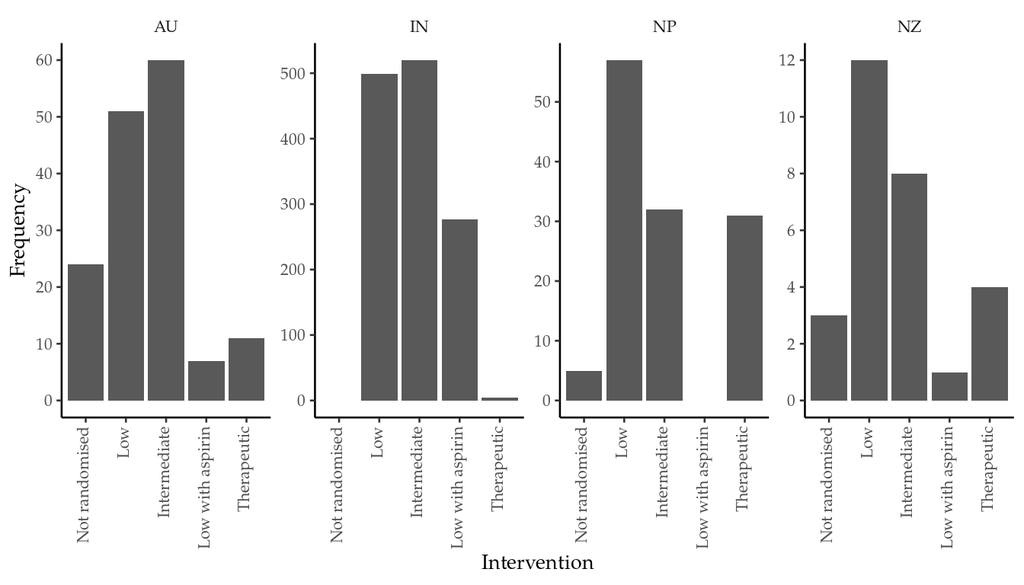

Figure 2: Allocation to anti-coagulation interventions by country.

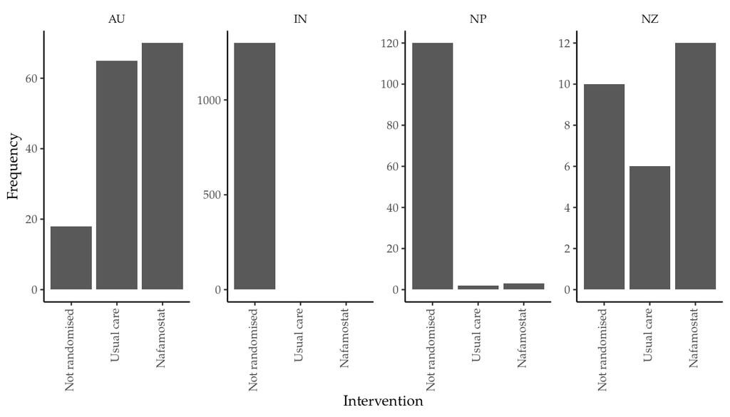

Figure 3: Allocation to anti-viral interventions by country.

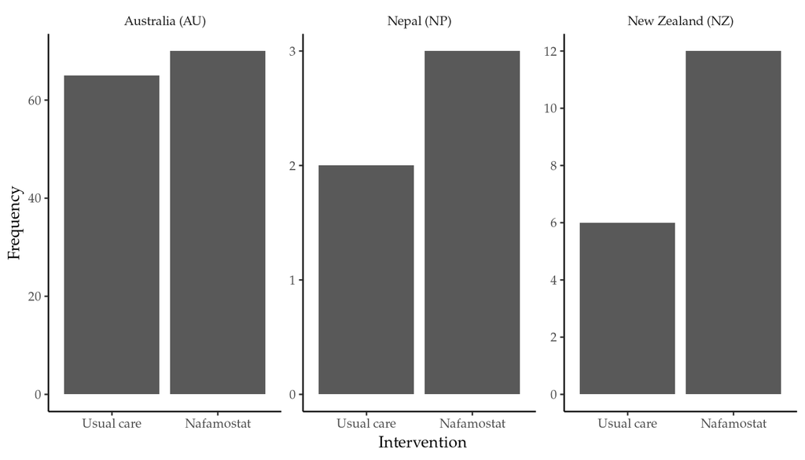

Figure 4: Allocation to anti-viral interventions by country.

## Site

Allocations to interventions by site of enrolment.

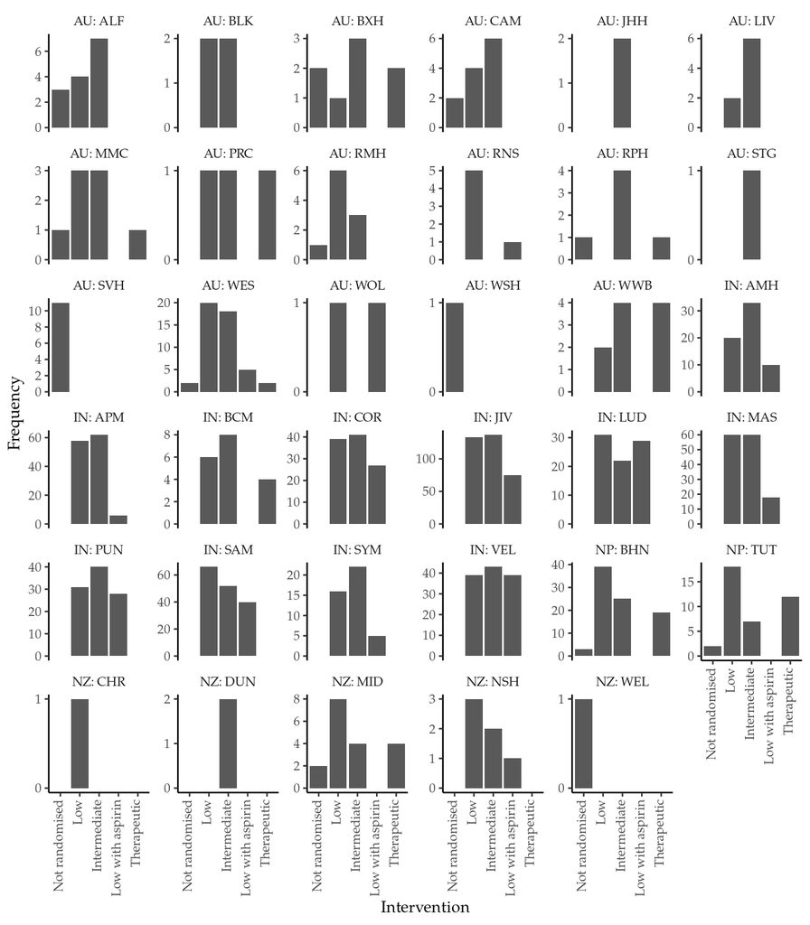

Figure 5: Allocation to anti-coagulation interventions by site

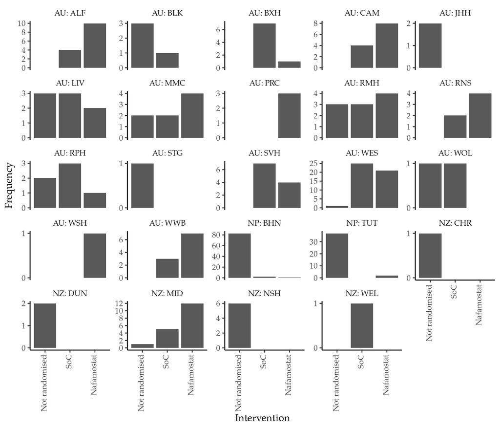

Figure 6: Allocation to anti-viral interventions by site

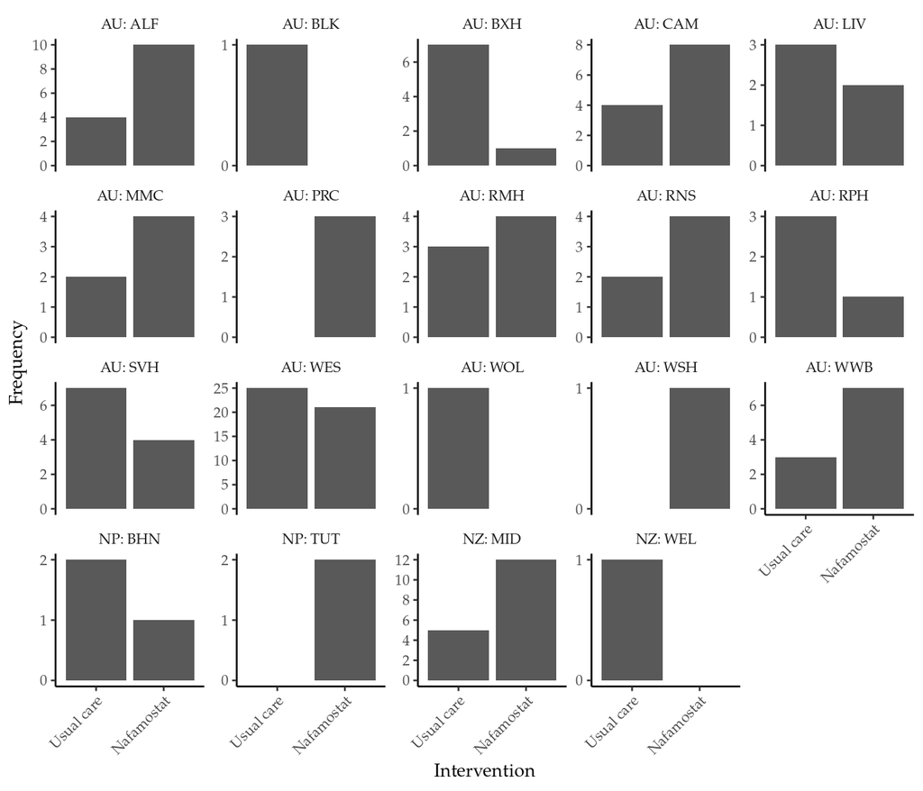

Figure 7: Allocation to anti-viral interventions by site

## Calender Time

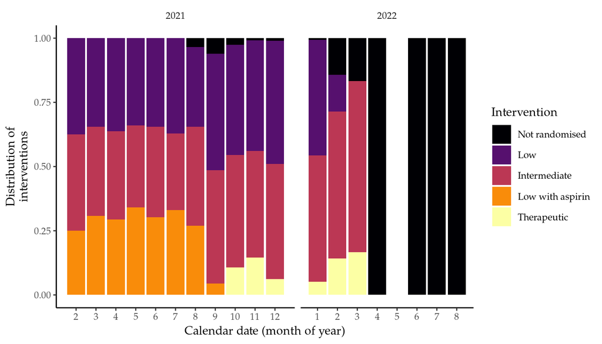

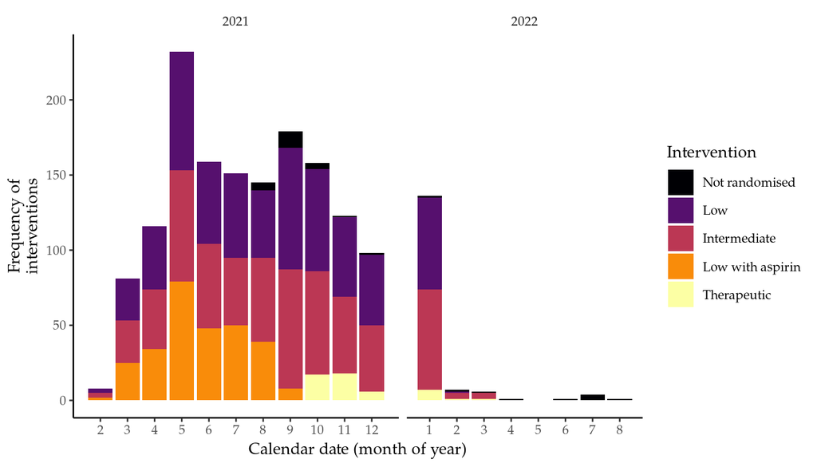

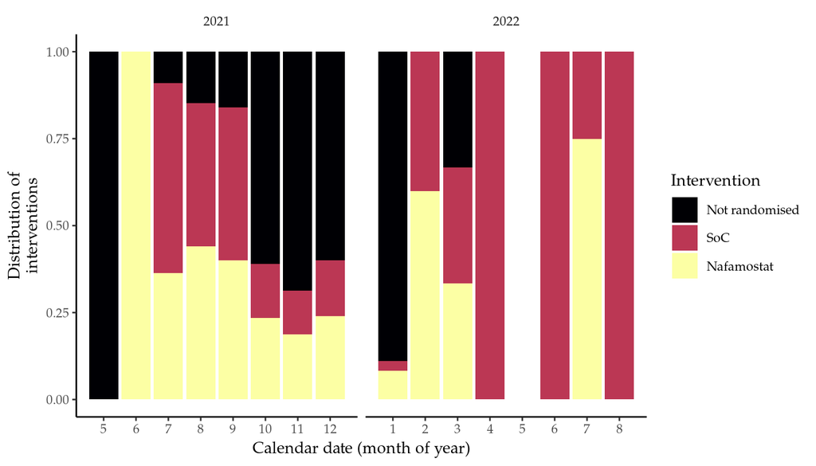

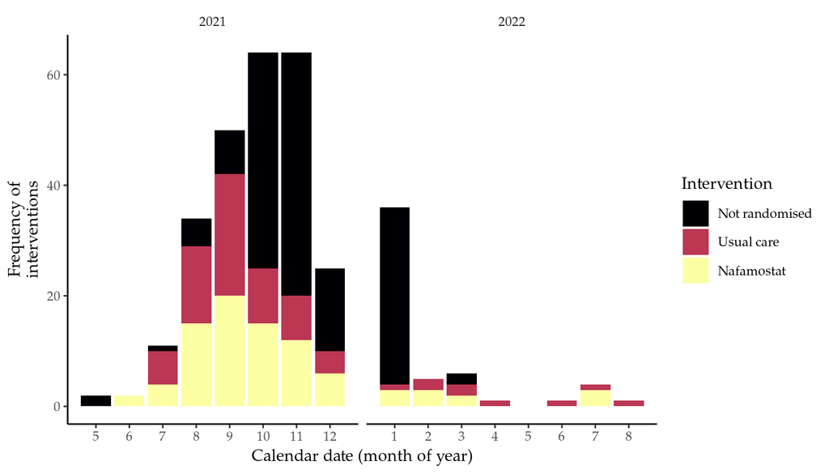

# Baseline Factors

The following provides an overview of the baseline covariates collected for individuals who were enrolled and did not withdraw from follow-up.

## Demographics

Baseline demographics are summarised by intervention in the following table.

| Variable | Anticoagulation Low dose (n = 610) | Anticoagulation Intermediate dose (n = 613) | Anticoagulation Low dose with aspirin (n = 283) | Anticoagulation Therapeutic dose (n = 50) | Overall (n = 1556) |
| --- | --- | --- | --- | --- | --- |
| Age (years), Median (IQR) | 48 (37, 60) | 48 (37, 61) | 50 (38, 62) | 58 (46, 69) | 49 (37, 61) |
| **Country** |  |  |  |  |  |
| India, n (\%) | 493 (81) | 516 (84) | 275 (97) | 4 (8) | 1288 (83) |
| Australia, n (\%) | 49 (8) | 59 (10) | 7 (2) | 11 (22) | 126 (8) |
| Nepal, n (\%) | 56 (9) | 31 (5) | 0 (0) | 31 (62) | 118 (8) |
| New Zealand, n (\%) | 12 (2) | 7 (1) | 1 (0) | 4 (8) | 24 (2) |
| **Sex** |  |  |  |  |  |
| Male, n (\%) | 354 (58) | 387 (63) | 157 (55) | 25 (50) | 923 (59) |
| Female, n (\%) | 256 (42) | 226 (37) | 126 (45) | 25 (50) | 633 (41) |
| **Weight (kg)** |  |  |  |  |  |
| Median, (IQR) | 68 (62, 76) | 70 (62, 77) | 68 (62, 76) | 66 (57, 80) | 69 (62, 76) |
| Missing, n (\%) | 0 (0) | 0 (0) | 0 (0) | 0 (0) | 0 (0) |
| **Vaccinated<sup>1</sup>** |  |  |  |  |  |
| Yes, n (\%) | 191 (31) | 220 (36) | 42 (15) | 27 (54) | 480 (31) |
| Missing, n (\%) | 32 (5) | 22 (4) | 29 (10) | 0 (0) | 83 (5) |
| **Ethnicity** |  |  |  |  |  |
| Indian, n (\%) | 494 (81) | 518 (85) | 275 (97) | 4 (8) | 1291 (83) |
| European, n (\%) | 21 (3) | 18 (3) | 4 (1) | 4 (8) | 47 (3) |
| Asian, n (\%) | 20 (3) | 12 (2) | 1 (0) | 10 (20) | 43 (3) |
| Pacific Islander, n (\%) | 13 (2) | 12 (2) | 2 (1) | 3 (6) | 30 (2) |
| Middle Eastern, n (\%) | 11 (2) | 11 (2) | 0 (0) | 0 (0) | 22 (1) |
| Maori, n (\%) | 3 (0) | 4 (1) | 0 (0) | 3 (6) | 10 (1) |
| African, n (\%) | 1 (0) | 0 (0) | 1 (0) | 0 (0) | 2 (0) |
| Aboriginal, n (\%) | 0 (0) | 1 (0) | 0 (0) | 1 (2) | 2 (0) |
| Latin American, n (\%) | 0 (0) | 1 (0) | 0 (0) | 0 (0) | 1 (0) |
| Other, n (\%) | 45 (7) | 28 (5) | 0 (0) | 23 (46) | 96 (6) |
| Unknown, n (\%) | 8 (1) | 9 (1) | 0 (0) | 3 (6) | 20 (1) |
| **Smoking** |  |  |  |  |  |
| Current, n (\%) | 17 (3) | 21 (3) | 3 (1) | 5 (10) | 46 (3) |
| Former, n (\%) | 74 (12) | 53 (9) | 15 (5) | 14 (28) | 156 (10) |
| Never, n (\%) | 519 (85) | 539 (88) | 265 (94) | 31 (62) | 1354 (87) |
| Missing, n (\%) | 0 (0) | 0 (0) | 0 (0) | 0 (0) | 0 (0) |

<sup>1</sup> Site LUD did not have ethics approval for collection of vaccination status.

Table 11: Baseline demographics for participants randomised into the anticoagulation domain.

| Variable | Antiviral Standard of care (n = 73) | Antiviral Nafamostat (n = 82) | Overall (n = 155) |
| --- | --- | --- | --- |
| Age (years), Median (IQR) | 46 (37, 60) | 44 (34, 60) | 45 (35, 60) |
| **Country** |  |  |  |
| India, n (\%) | 0 (0) | 0 (0) | 0 (0) |
| Australia, n (\%) | 65 (89) | 67 (82) | 132 (85) |
| Nepal, n (\%) | 2 (3) | 3 (4) | 5 (3) |
| New Zealand, n (\%) | 6 (8) | 12 (15) | 18 (12) |
| **Sex** |  |  |  |
| Male, n (\%) | 39 (53) | 56 (68) | 95 (61) |
| Female, n (\%) | 34 (47) | 26 (32) | 60 (39) |
| **Weight (kg)** |  |  |  |
| Median, (IQR) | 90 (70, 106) | 90 (79, 110) | 90 (78, 108) |
| Missing, n (\%) | 0 (0) | 0 (0) | 0 (0) |
| **Vaccinated<sup>1</sup>** |  |  |  |
| Yes, n (\%) | 27 (37) | 31 (38) | 58 (37) |
| Missing, n (\%) | 7 (10) | 1 (1) | 8 (5) |
| **Ethnicity** |  |  |  |
| Indian, n (\%) | 1 (1) | 1 (1) | 2 (1) |
| European, n (\%) | 18 (25) | 27 (33) | 45 (29) |
| Asian, n (\%) | 6 (8) | 6 (7) | 12 (8) |
| Pacific Islander, n (\%) | 12 (16) | 12 (15) | 24 (15) |
| Middle Eastern, n (\%) | 9 (12) | 11 (13) | 20 (13) |
| Maori, n (\%) | 1 (1) | 7 (9) | 8 (5) |
| African, n (\%) | 2 (3) | 0 (0) | 2 (1) |
| Aboriginal, n (\%) | 3 (4) | 1 (1) | 4 (3) |
| Latin American, n (\%) | 1 (1) | 0 (0) | 1 (1) |
| Other, n (\%) | 6 (8) | 9 (11) | 15 (10) |
| Unknown, n (\%) | 17 (23) | 11 (13) | 28 (18) |
| **Smoking** |  |  |  |
| Current, n (\%) | 8 (11) | 12 (15) | 20 (13) |
| Former, n (\%) | 22 (30) | 16 (20) | 38 (25) |
| Never, n (\%) | 43 (59) | 54 (66) | 97 (63) |
| Missing, n (\%) | 0 (0) | 0 (0) | 0 (0) |

<sup>1</sup> Site LUD did not have ethics approval for collection of vaccination status.

Table 12: Baseline demographics for participants randomised into the antiviral domain.

## Co-morbidities

Baseline co-morbidities are summarised by anti-coagulation intervention in the following table.

| Comorbidity | Anticoagulation Low dose (n = 610) | Anticoagulation Intermediate dose (n = 613) | Anticoagulation Low dose with aspirin (n = 283) | Anticoagulation Therapeutic dose (n = 50) | Overall (n = 1556) |
| --- | --- | --- | --- | --- | --- |
| None, n (\%) | 364 ( 60) | 378 ( 62) | 166 ( 59) | 19 ( 38) | 927 ( 60) |
| Hypertension, n (\%) | 147 ( 24) | 140 ( 23) | 68 ( 24) | 14 ( 28) | 369 ( 24) |
| Diabetes, n (\%) | 140 ( 23) | 139 ( 23) | 78 ( 28) | 11 ( 22) | 368 ( 24) |
| Obesity, n (\%) | 23 ( 4) | 22 ( 4) | 3 ( 1) | 5 ( 10) | 53 ( 3) |
| Asthma, n (\%) | 19 ( 3) | 16 ( 3) | 6 ( 2) | 4 ( 8) | 45 ( 3) |
| Chronic lung disease, n (\%) | 16 ( 3) | 13 ( 2) | 1 ( 0) | 7 ( 14) | 37 ( 2) |
| Chronic cardiac disease, n (\%) | 11 ( 2) | 15 ( 2) | 1 ( 0) | 2 ( 4) | 29 ( 2) |
| Obstructive sleep apnoea, n (\%) | 3 ( 0) | 2 ( 0) | 2 ( 1) | 0 ( 0) | 7 ( 0) |
| Iatrogenic immunosuppression, n (\%) | 1 ( 0) | 6 ( 1) | 0 ( 0) | 0 ( 0) | 7 ( 0) |
| Chronic kidney disease, n (\%) | 0 ( 0) | 5 ( 1) | 1 ( 0) | 0 ( 0) | 6 ( 0) |
| Malignant neoplasm, n (\%) | 1 ( 0) | 2 ( 0) | 0 ( 0) | 1 ( 2) | 4 ( 0) |
| Moderate or severe liver disease, n (\%) | 2 ( 0) | 1 ( 0) | 0 ( 0) | 0 ( 0) | 3 ( 0) |
| Dialysis, n (\%) | 0 ( 0) | 1 ( 0) | 0 ( 0) | 0 ( 0) | 1 ( 0) |
| HIV infection, n (\%) | 1 ( 0) | 0 ( 0) | 0 ( 0) | 0 ( 0) | 1 ( 0) |
| Dementia, n (\%) | 0 ( 0) | 0 ( 0) | 0 ( 0) | 0 ( 0) | 0 ( 0) |
| Missing, n (\%) | 0 ( 0) | 0 ( 0) | 0 ( 0) | 0 ( 0) | 0 ( 0) |

Table 13: Baseline comorbidities for participants randomised into the anticoagulation domain.

| Comorbidity | Antiviral Standard of care (n = 73) | Antiviral Nafamostat (n = 82) | Overall (n = 155) |
| --- | --- | --- | --- |
| None, n (\%) | 31 ( 42) | 34 ( 41) | 65 ( 42) |
| Obesity, n (\%) | 19 ( 26) | 22 ( 27) | 41 ( 26) |
| Hypertension, n (\%) | 16 ( 22) | 17 ( 21) | 33 ( 21) |
| Diabetes, n (\%) | 16 ( 22) | 15 ( 18) | 31 ( 20) |
| Asthma, n (\%) | 10 ( 14) | 10 ( 12) | 20 ( 13) |
| Chronic lung disease, n (\%) | 7 ( 10) | 6 ( 7) | 13 ( 8) |
| Chronic cardiac disease, n (\%) | 3 ( 4) | 6 ( 7) | 9 ( 6) |
| Iatrogenic immunosuppression, n (\%) | 2 ( 3) | 4 ( 5) | 6 ( 4) |
| Obstructive sleep apnoea, n (\%) | 3 ( 4) | 2 ( 2) | 5 ( 3) |
| Chronic kidney disease, n (\%) | 2 ( 3) | 2 ( 2) | 4 ( 3) |
| Malignant neoplasm, n (\%) | 1 ( 1) | 2 ( 2) | 3 ( 2) |
| Dialysis, n (\%) | 0 ( 0) | 0 ( 0) | 0 ( 0) |
| Moderate or severe liver disease, n (\%) | 0 ( 0) | 0 ( 0) | 0 ( 0) |
| Dementia, n (\%) | 0 ( 0) | 0 ( 0) | 0 ( 0) |
| HIV infection, n (\%) | 0 ( 0) | 0 ( 0) | 0 ( 0) |
| Missing, n (\%) | 0 ( 0) | 0 ( 0) | 0 ( 0) |

Table 14: Baseline comorbidities for participants randomised into the antiviral domain.

## Prognostics

Baseline prognostics are summarised by anti-coagulation intervention in the following table.

| Variable | Anticoagulation Low dose (n = 610) | Anticoagulation Intermediate dose (n = 613) | Anticoagulation Low dose with aspirin (n = 283) | Anticoagulation Therapeutic dose (n = 50) | Overall (n = 1556) |
| --- | --- | --- | --- | --- | --- |
| **Was the patient on room air for any of the preceding 24 hours?** |  |  |  |  |  |
| Yes, n (\%) | 460 (75) | 460 (75) | 224 (79) | 39 (78) | 1183 (76) |
| Missing, n (\%) | 8 (1) | 9 (1) | 8 (3) | 0 (0) | 25 (2) |
| **Was the patient's GCS < 15?** |  |  |  |  |  |
| Yes, n (\%) | 63 (10) | 65 (11) | 6 (2) | 2 (4) | 136 (9) |
| Missing, n (\%) | 125 (20) | 135 (22) | 60 (21) | 0 (0) | 320 (21) |
| **Peripheral oxygen saturation (SpO2) on room air (Lowest)** |  |  |  |  |  |
| Median (IQR) | 95 (94, 97) | 96 (94, 97) | 96 (94, 97) | 94 (92, 96) | 96 (94, 97) |
| Missing, n (\%) | 150 (25) | 153 (25) | 59 (21) | 11 (22) | 373 (24) |
| **Highest respiratory rate (breaths/minute)** |  |  |  |  |  |
| Median (IQR) | 22 (21, 25) | 22 (21, 26) | 22 (20, 26) | 22 (20, 24) | 22 (21, 26) |
| Missing, n (\%) | 0 (0) | 1 (0) | 0 (0) | 0 (0) | 1 (0) |
| **Highest recorded Urea in the last 24 hours (mmol/L)** |  |  |  |  |  |
| Median (IQR) | 4 (3, 5) | 5 (4, 6) | 4 (3, 6) | 4 (3, 6) | 4 (3, 6) |
| Missing, n (\%) | 30 (5) | 33 (5) | 16 (6) | 1 (2) | 80 (5) |
| **Highest recorded CRP in the last 24 hours (mg/L)** |  |  |  |  |  |
| Median (IQR) | 199 (61, 400) | 200 (67, 395) | 300 (135, 516) | 71 (53, 175) | 220 (68, 410) |
| Missing, n (\%) | 74 (12) | 59 (10) | 18 (6) | 29 (58) | 180 (12) |
| **APTT\\textsuperscript{1}** |  |  |  |  |  |
| Median (IQR) | 33 (29, 36) | 33 (30, 36) | 32 (28, 37) | 33 (28, 38) | 33 (29, 36) |
| Missing, n (\%) | 430 (70) | 439 (72) | 195 (69) | 35 (70) | 1099 (71) |
| **INR\\textsuperscript{1}** |  |  |  |  |  |
| Mean (SD) | 1.19 (0.39) | 1.23 (0.58) | 1.32 (1.34) | 1.12 (0.18) | 1.23 (0.72) |
| Missing, n (\%) | 103 (17) | 105 (17) | 47 (17) | 7 (14) | 262 (17) |
| **Fibrinogen\\textsuperscript{1} (g/L)** |  |  |  |  |  |
| Mean (SD) | 5.19 (2.01) | 5.20 (1.60) | 4.75 (1.40) | 6.49 (1.52) | 5.14 (1.71) |
| Missing, n (\%) | 564 (92) | 555 (91) | 243 (86) | 42 (84) | 1404 (90) |
| **Prothrombin time\\textsuperscript{1} (sec)** |  |  |  |  |  |
| Median (IQR) | 14 (13, 17) | 14 (13, 17) | 15 (13, 16) | 13 (12, 14) | 14 (13, 16) |
| Missing, n (\%) | 193 (32) | 204 (33) | 116 (41) | 10 (20) | 523 (34) |
| **Taking aspirin** |  |  |  |  |  |
| Yes, n (\%) | 20 (3) | 25 (4) | 2 (1) | 3 (6) | 50 (3) |
| Missing, n (\%) | 0 (0) | 0 (0) | 0 (0) | 0 (0) | 0 (0) |
| **Time from onset of symptoms to hospitalisation** |  |  |  |  |  |
| Median (IQR) | 5 (3, 7) | 5 (3, 6) | 4 (2, 6) | 4 (3, 6) | 4 (3, 6) |
| **Time from hospitalisation to randomisation** |  |  |  |  |  |
| Median (IQR) | 1 (0, 2) | 1 (0, 2) | 1 (1, 2) | 1 (1, 1) | 1 (0, 2) |
| **D-dimer** |  |  |  |  |  |
| Test performed, n(\%) | 494 (81) | 514 (84) | 247 (87) | 17 (34) | 1272 (82) |
| Out of range, n(\%) | 182 (37) | 177 (35) | 63 (26) | 10 (59) | 432 (34) |

<sup>1</sup> For APTT, INR, Fibrinogen, and Prothrombin only at least one required.

Table 15: Baseline prognostics for participants randomised into the anticoagulation domain.

| Variable | Antiviral Standard of care (n = 73) | Antiviral Nafamostat (n = 82) | Overall (n = 155) |
| --- | --- | --- | --- |
| **Was the patient on room air for any of the preceding 24 hours?** |  |  |  |
| Yes, n (\%) | 48 (66) | 42 (51) | 90 (58) |
| Missing, n (\%) | 0 (0) | 0 (0) | 0 (0) |
| **Was the patient's GCS < 15?** |  |  |  |
| Yes, n (\%) | 5 (7) | 4 (5) | 9 (6) |
| Missing, n (\%) | 1 (1) | 0 (0) | 1 (1) |
| **Peripheral oxygen saturation (SpO2) on room air (Lowest)** |  |  |  |
| Median (IQR) | 93 (90, 95) | 93 (92, 95) | 93 (91, 95) |
| Missing, n (\%) | 25 (34) | 40 (49) | 65 (42) |
| **Highest respiratory rate (breaths/minute)** |  |  |  |
| Median (IQR) | 24 (20, 28) | 24 (21, 28) | 24 (21, 28) |
| Missing, n (\%) | 1 (1) | 0 (0) | 1 (1) |
| **Highest recorded Urea in the last 24 hours (mmol/L)** |  |  |  |
| Median (IQR) | 5 (4, 7) | 5 (4, 7) | 5 (4, 7) |
| Missing, n (\%) | 4 (5) | 4 (5) | 8 (5) |
| **Highest recorded CRP in the last 24 hours (mg/L)** |  |  |  |
| Median (IQR) | 68 (32, 113) | 53 (28, 74) | 58 (28, 102) |
| Missing, n (\%) | 5 (7) | 11 (13) | 16 (10) |
| **APTT\\textsuperscript{1}** |  |  |  |
| Median (IQR) | 33 (31, 36) | 33 (30, 36) | 33 (30, 36) |
| Missing, n (\%) | 23 (32) | 20 (24) | 43 (28) |
| **INR\\textsuperscript{1}** |  |  |  |
| Mean (SD) | 1.09 (0.09) | 1.07 (0.11) | 1.08 (0.10) |
| Missing, n (\%) | 25 (34) | 26 (32) | 51 (33) |
| **Fibrinogen\\textsuperscript{1} (g/L)** |  |  |  |
| Mean (SD) | 5.76 (2.08) | 5.62 (1.56) | 5.68 (1.79) |
| Missing, n (\%) | 42 (58) | 42 (51) | 84 (54) |
| **Prothrombin time\\textsuperscript{1} (sec)** |  |  |  |
| Median (IQR) | 13 (13, 14) | 13 (13, 14) | 13 (13, 14) |
| Missing, n (\%) | 30 (41) | 29 (35) | 59 (38) |
| **Taking aspirin** |  |  |  |
| Yes, n (\%) | 4 (5) | 8 (10) | 12 (8) |
| Missing, n (\%) | 18 (25) | 14 (17) | 32 (21) |
| **Time from onset of symptoms to hospitalisation** |  |  |  |
| Median (IQR) | 6 (4, 8) | 6 (4, 8) | 6 (4, 8) |
| **Time from hospitalisation to randomisation** |  |  |  |
| Median (IQR) | 1 (1, 2) | 1 (1, 2) | 1 (1, 2) |
| **D-dimer** |  |  |  |
| Test performed, n(\%) | 54 (74) | 51 (62) | 105 (68) |
| Out of range, n(\%) | 35 (65) | 32 (64) | 67 (64) |

<sup>1</sup> For APTT, INR, Fibrinogen, and Prothrombin only at least one required.

Table 16: Baseline prognostics for participants randomised into the antiviral domain.

## Age

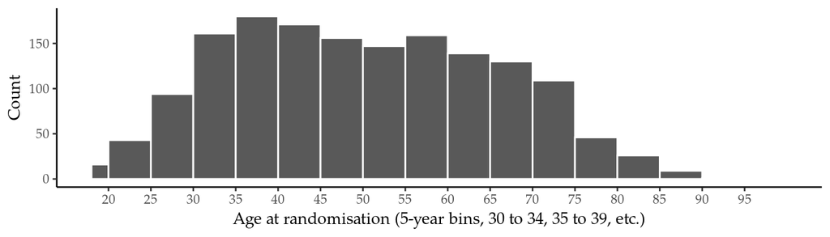

Figure 12: Distribution of age

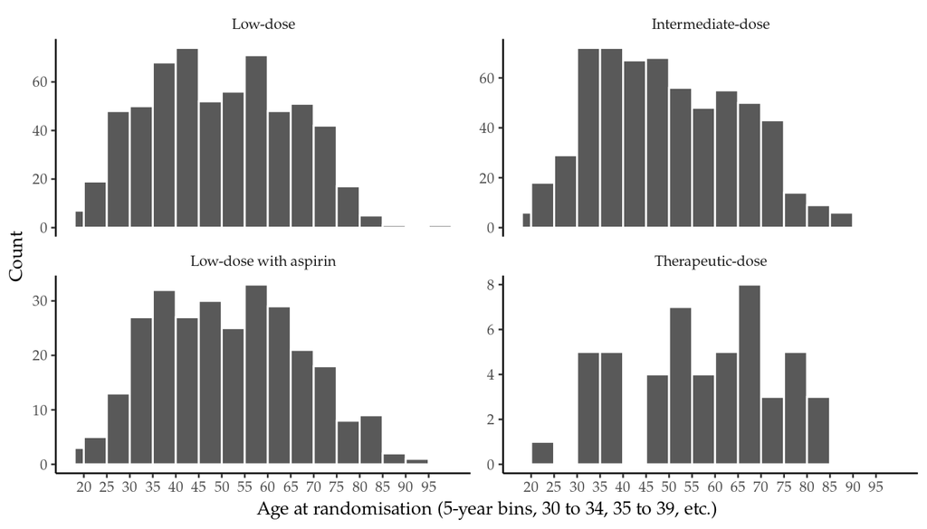

Figure 13: Distribution of age by anti-coagulation intervention

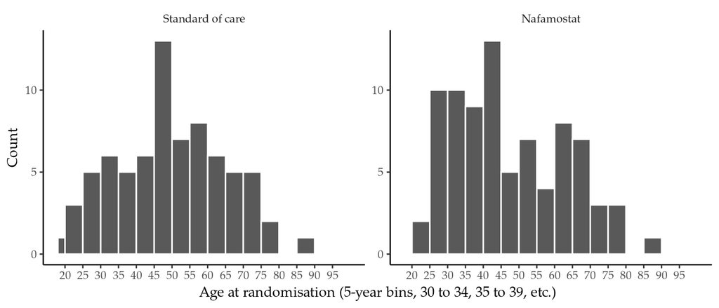

Figure 14: Distribution of age by anti-viral intervention.

## Weight

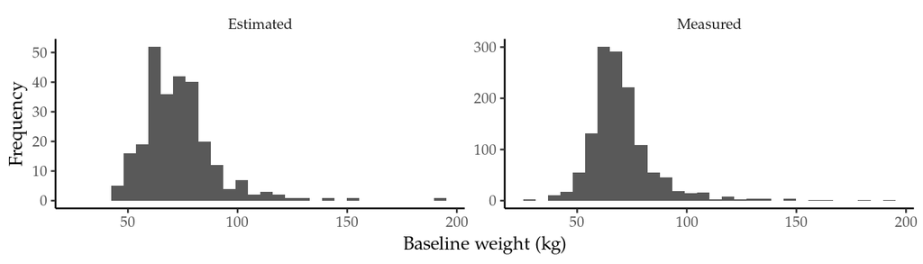

Figure 15: Distribution of weight

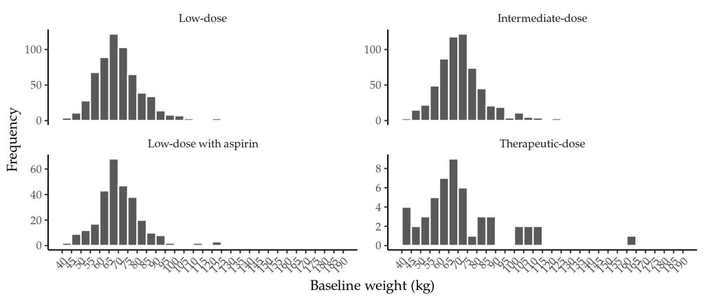

Figure 16: Distribution of weight by anti-coagulation intervention

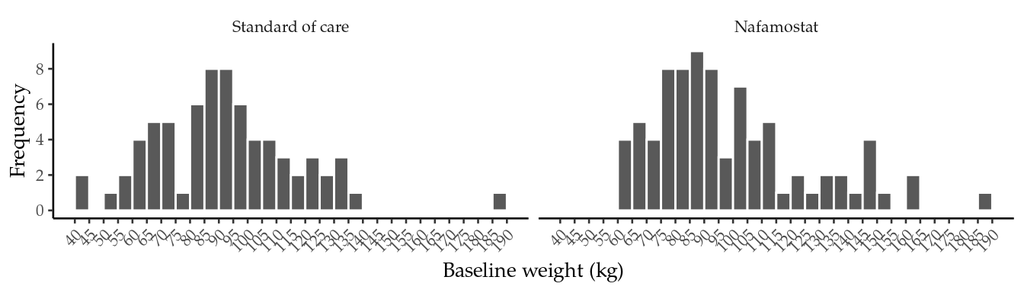

Figure 17: Distribution of weight by anti-viral intervention

## Date since first symptoms

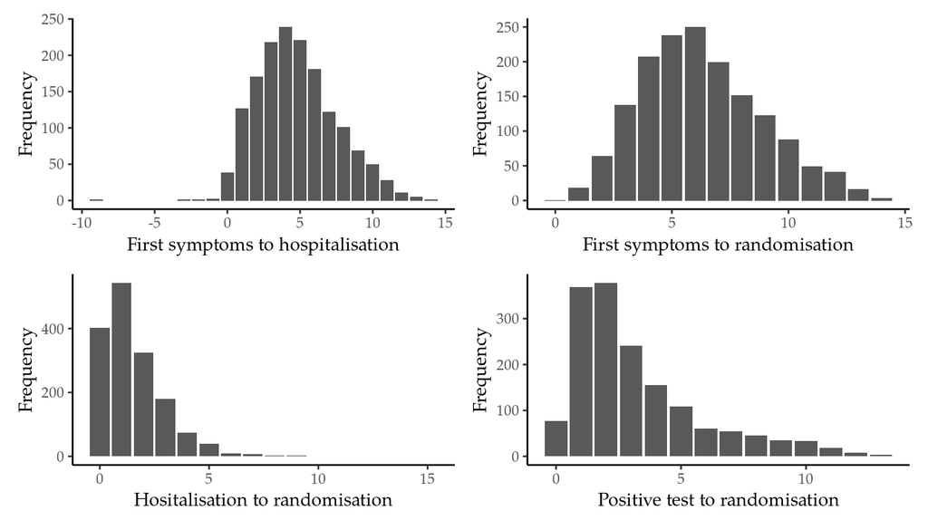

Days between events for hospitalisation, randomisation, symptom onset, and first positive test.

## Oxygen Requirement

For supplemental oxygen requirement at baseline the relevant fields are:

- `BAS_OnRoomAir24hrs`
- `BAS_OnRoomAir24hrsUnknown`
- `BAS_PeripheralOxygen`

The logic is:

- if `BAS_OnRoomAir24hrs == "No"` then `supp_oxy = 1`
- if `BAS_OnRoomAir24hrs == "Yes" & BAS_PeripheralOxygen < 94` then `supp_oxy = 1`
- if `BAS_OnRoomAir24hrs == "Yes" & BAS_PeripheralOxygen >= 94` then `supp_oxy = 0`

There were 25 participants who had unknown supplemental oxygen status. For the purpose of analysis, when this covariate is included, it is assumed that these participants *did not* require supplemental oxygen at baseline.

| Supplemental oxygen at baseline | Not randomised<br>to antiviral | Standard<br>of care | Nafamostat<br> |
| --- | --- | --- | --- |
| 0 | 875 | 23 | 19 |
| 1 | 533 | 50 | 63 |
| NA | 25 | 0 | 0 |

| Supplemental oxygen at baseline | Not randomised<br>to anticoagulation | Low<br>dose | Intermediate<br>dose | Low dose<br>with aspirin | Therapeutic<br>dose |
| --- | --- | --- | --- | --- | --- |
| 0 | 9 | 350 | 363 | 171 | 24 |
| 1 | 23 | 252 | 241 | 104 | 26 |
| NA | 0 | 8 | 9 | 8 | 0 |

## C-Reactive Protein

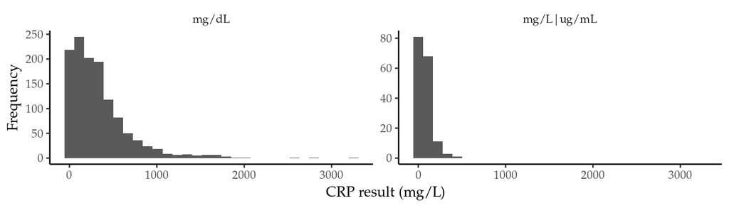

Figure 18: Distribution of CRP

It looks like there may be an issue with the conversion of CRP units or an issue with mis-specification of the reported units.

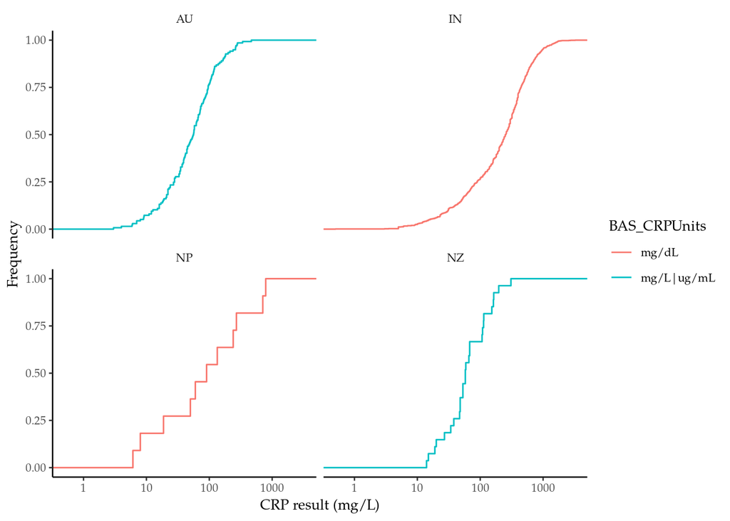

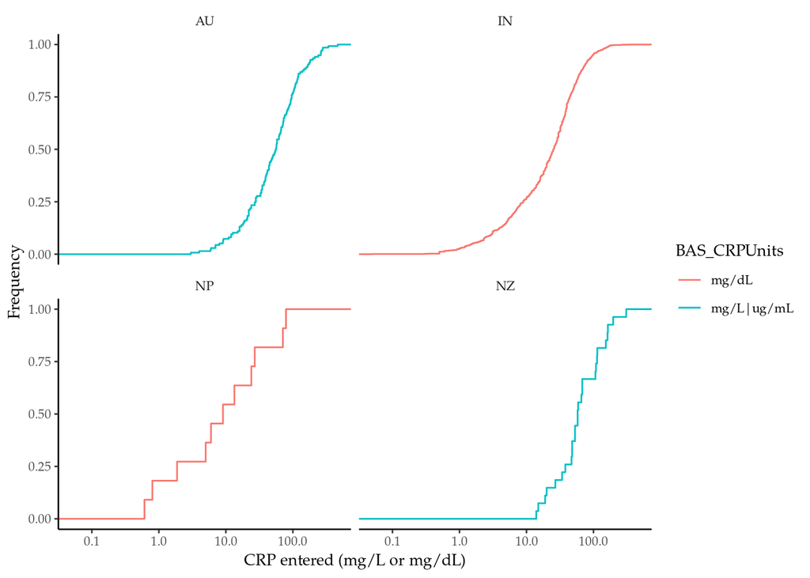

This was investigated with sites and corrections made to the reported units.

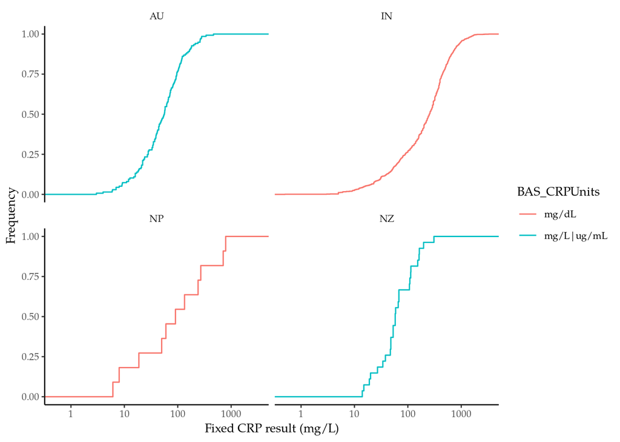

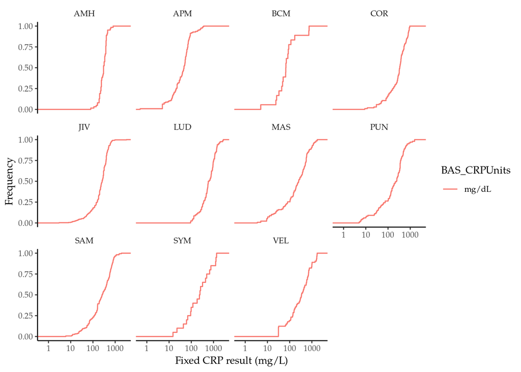

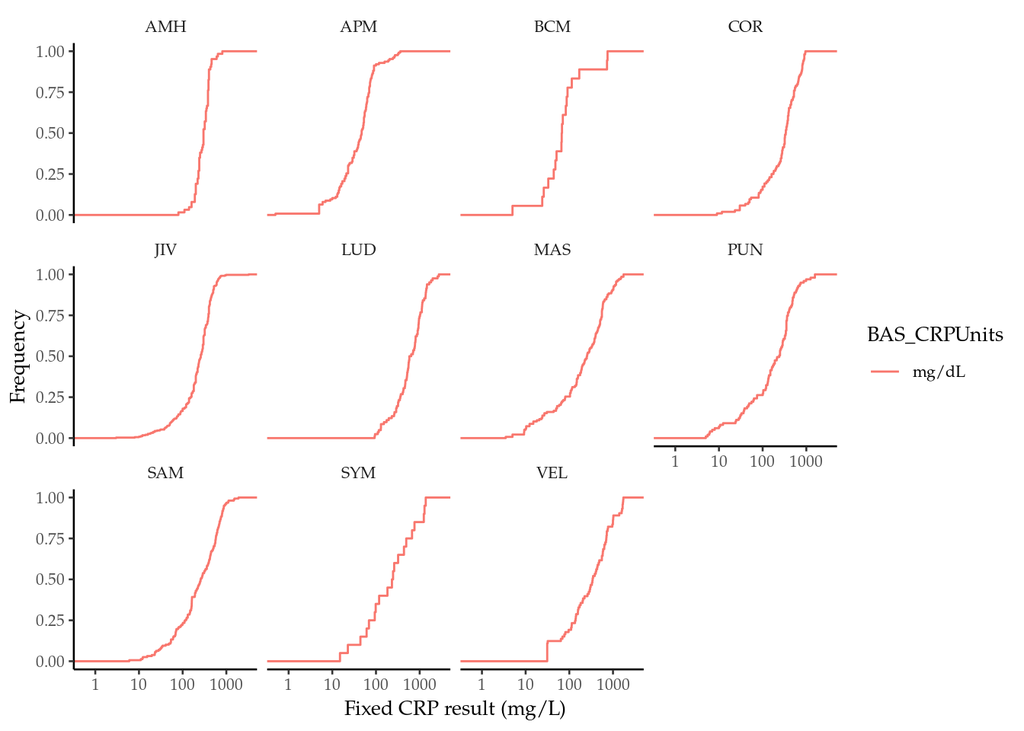

# Drugs Received During Hospital Stay

| Drug received | Anticoagulation Low dose (n = 610) | Anticoagulation Intermediate dose (n = 613) | Anticoagulation Low dose with aspirin (n = 283) | Anticoagulation Therapeutic dose (n = 50) | Overall (n = 1556) |
| --- | --- | --- | --- | --- | --- |
| Antibacterial drugs, n (\%) | 449 (74) | 443 (72) | 231 (82) | 38 (76) | 1161 (75) |
| **Antivirals** |  |  |  |  |  |
| No antiviral, n (\%) | 125 (20) | 120 (20) | 44 (16) | 39 (78) | 328 (21) |
| Camostat, n (\%) | 0 (0) | 0 (0) | 0 (0) | 0 (0) | 0 (0) |
| Favipiravir, n (\%) | 97 (16) | 100 (16) | 34 (12) | 0 (0) | 231 (15) |
| Ivermectin, n (\%) | 201 (33) | 200 (33) | 91 (32) | 0 (0) | 492 (32) |
| Remdesivir, n (\%) | 286 (47) | 289 (47) | 169 (60) | 10 (20) | 754 (48) |
| Other antiviral, n (\%) | 3 (0) | 1 (0) | 1 (0) | 0 (0) | 5 (0) |
| **Immunomodulatory** |  |  |  |  |  |
| No immunomodulatory, n (\%) | 60 (10) | 68 (11) | 38 (13) | 6 (12) | 172 (11) |
| Anakinra, n (\%) | 0 (0) | 0 (0) | 0 (0) | 0 (0) | 0 (0) |
| Corticosteroids, n (\%) | 396 (65) | 388 (63) | 183 (65) | 37 (74) | 1004 (65) |
| Sarilumab, n (\%) | 0 (0) | 0 (0) | 0 (0) | 0 (0) | 0 (0) |
| Azithromycin, n (\%) | 105 (17) | 108 (18) | 38 (13) | 5 (10) | 256 (16) |
| Tocilizumab, n (\%) | 12 (2) | 11 (2) | 5 (2) | 2 (4) | 30 (2) |
| Baricitinib, n (\%) | 36 (6) | 50 (8) | 11 (4) | 6 (12) | 103 (7) |
| Ruxolitinib, n (\%) | 0 (0) | 0 (0) | 0 (0) | 0 (0) | 0 (0) |
| Tofacitinib, n (\%) | 11 (2) | 13 (2) | 5 (2) | 0 (0) | 29 (2) |
| Zinc, n (\%) | 388 (64) | 394 (64) | 173 (61) | 13 (26) | 968 (62) |
| Other immunomodulatory, n (\%) | 20 (3) | 20 (3) | 11 (4) | 1 (2) | 52 (3) |

Table 17: Drugs received during hospital stay for participants randomised into the anticoagulation domain.

| Drug received | Antiviral Standard of care (n = 73) | Antiviral Nafamostat (n = 82) | Overall (n = 155) |
| --- | --- | --- | --- |
| Antibacterial drugs, n (\%) | 33 (45) | 38 (46) | 71 (46) |
| **Antivirals** |  |  |  |
| No antiviral, n (\%) | 28 (38) | 36 (44) | 64 (41) |
| Camostat, n (\%) | 0 (0) | 0 (0) | 0 (0) |
| Favipiravir, n (\%) | 0 (0) | 0 (0) | 0 (0) |
| Ivermectin, n (\%) | 1 (1) | 1 (1) | 2 (1) |
| Remdesivir, n (\%) | 39 (53) | 39 (48) | 78 (50) |
| Other antiviral, n (\%) | 5 (7) | 3 (4) | 8 (5) |
| **Immunomodulatory** |  |  |  |
| No immunomodulatory, n (\%) | 10 (14) | 9 (11) | 19 (12) |
| Anakinra, n (\%) | 0 (0) | 0 (0) | 0 (0) |
| Corticosteroids, n (\%) | 55 (75) | 70 (85) | 125 (81) |
| Sarilumab, n (\%) | 0 (0) | 0 (0) | 0 (0) |
| Azithromycin, n (\%) | 6 (8) | 9 (11) | 15 (10) |
| Tocilizumab, n (\%) | 5 (7) | 3 (4) | 8 (5) |
| Baricitinib, n (\%) | 24 (33) | 38 (46) | 62 (40) |
| Ruxolitinib, n (\%) | 0 (0) | 0 (0) | 0 (0) |
| Tofacitinib, n (\%) | 0 (0) | 0 (0) | 0 (0) |
| Zinc, n (\%) | 1 (1) | 2 (2) | 3 (2) |
| Other immunomodulatory, n (\%) | 3 (4) | 3 (4) | 6 (4) |

Table 18: Drugs received during hospital stay for participants randomised into the antiviral domain.

# Anticoagulation Received

```
# A tibble: 5 × 3
  anticoag                                                      A1        A2
  <chr>                                                         <chr>     <chr>
1 Intermediate Dose                                             25 (0.34) 35 (0…
2 No non-trial anticoagulants were given during hospitalisation 10 (0.14) 6 (0.…
3 Prophylactic Dose                                             33 (0.45) 27 (0…
4 Therapeutic Dose                                              4 (0.05)  14 (0…
5 Unknown                                                       1 (0.01)  0 (0.…
```

# Table 1

[output not shown]

# Ethnicities revise

```
# A tibble: 2 × 4
  AAssignment pacific maori  both
  <chr>         <int> <int> <int>
1 A1               12     1     0
2 A2               12     7     0
```

```
# A tibble: 2 × 2
  `|...`     n
  <lgl>  <int>
1 FALSE    114
2 TRUE      41
```